# Cartographie : ggmap, sf et leaflet

```r
library(tidyverse)
theme_set(theme_classic())
```

# Le package **ggmap**

**ggmap** est un package permettant de faire de la cartographie. On pourra consulter [cet article](https://journal.r-project.org/archive/2013-1/kahle-wickham.pdf) pour plus de détails.

**ggmap** permet de récupérer facilement des fonds de carte. Par exemple :

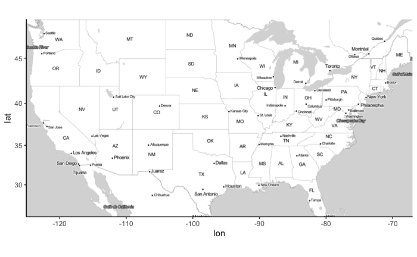

```r
library(ggmap)
us <- c(left = -125, bottom = 25.75, right = -67, top = 49)
map <- get_stamenmap(us, zoom = 5, maptype = "toner-lite")
ggmap(map)
```

On peut utiliser **dplyr** pour les opérations

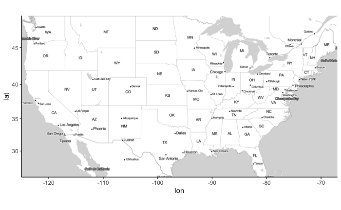

```r
get_stamenmap(us, zoom = 5, maptype = "toner-lite") %>% ggmap()
```

Pour l’Europe on fait

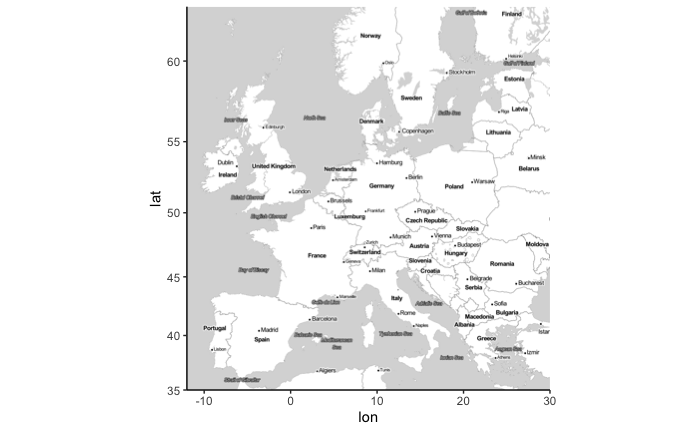

```r
europe <- c(left = -12, bottom = 35, right = 30, top = 63)
get_stamenmap(europe, zoom = 5,"toner-lite") %>% ggmap()
```

On peut également changer le fond de carte

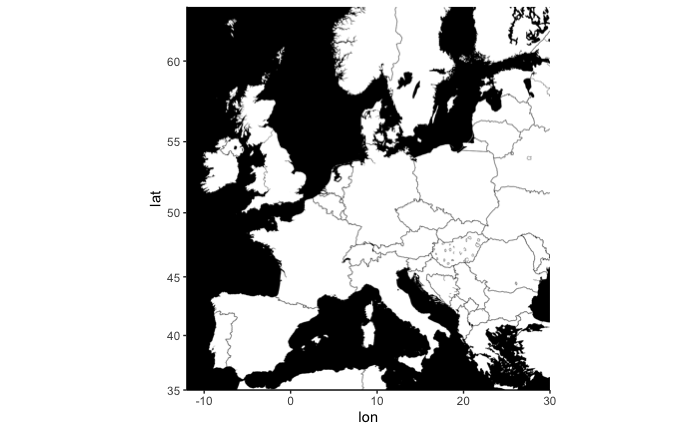

```r
get_stamenmap(europe, zoom = 5,"toner-background") %>% ggmap()
```

Pour la france, on aura

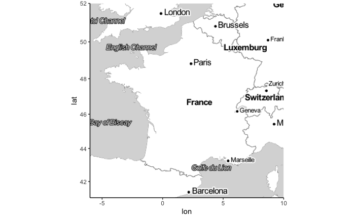

```r
fr <- c(left = -6, bottom = 41, right = 10, top = 52)
get_stamenmap(fr, zoom = 5,"toner-lite") %>% ggmap()
```

La fonction **geocode** qui permettait de récupérer des latitudes et longitudes n’est plus gratuite. On propose d’utiliser la fonction suivante :

```r
if (!(require(jsonlite))) install.packages("jsonlite")
geocodeGratuit <- function(adresses){
# adresses est un vecteur contenant toutes les adresses sous forme de chaine de caracteres
  nominatim_osm <- function(address = NULL){
    ## details: http://wiki.openstreetmap.org/wiki/Nominatim
    ## fonction nominatim_osm proposée par D.Kisler
    if(suppressWarnings(is.null(address)))  return(data.frame())
    tryCatch(
      d <- jsonlite::fromJSON(
        gsub('\\@addr\\@', gsub('\\s+', '\\%20', address),
             'http://nominatim.openstreetmap.org/search/@addr@?format=json&addressdetails=0&limit=1')
      ), error = function(c) return(data.frame())
    )
    if(length(d) == 0) return(data.frame())
    return(c(as.numeric(d$lon), as.numeric(d$lat)))
  }
  tableau <- t(sapply(adresses,nominatim_osm))
  colnames(tableau) <- c("lon","lat")
  return(tableau)
}
```

Cette fonction permet de récupérer les latitudes et longitudes de lieux à spécifier :

```r
geocodeGratuit("the white house")
```

```
                      lon     lat
the white house -77.03655 38.8977
```

```r
geocodeGratuit("Paris")
```

```
           lon     lat
Paris 2.351462 48.8567
```

```r
geocodeGratuit("Rennes")
```

```
            lon      lat
Rennes -1.68002 48.11134
```

### Exercice 1

1. Récupérer les latitudes et longitudes de Paris, Lyon et Marseille et représenter ces 3 villes sur une carte de la france.
2. Le fichier **villes_fr.csv** contient les populations des 30 plus grandes villes de france. Représenter à l’aide d’un point les 30 plus grandes villes de france. On fera varier la taille du point en fonction de la population en 2014.

Enfin, il est bien entendu possible de faire des cartes en ayant à disposition des coordonnées de frontières. Ces coordonnées peuvent se trouver sur le net ou dans certains packages **R** tels que **maps** :

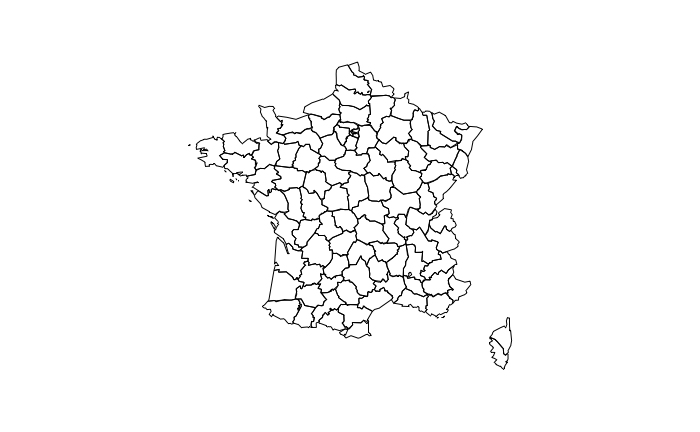

```r
library(maps)
france <- map(database="france")
```

```r
names(france)
```

```
[1] "x"     "y"     "range" "names"
```

On peut alors utiliser **ggplot** :

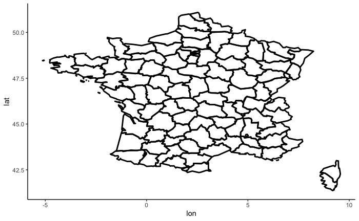

```r
fr1 <- tibble(lon=france$x,lat=france$y)
ggplot(fr1)+geom_path(aes(y=lat,x=lon),size=1)+theme_classic()
```

On pourra supprimer les axes avec

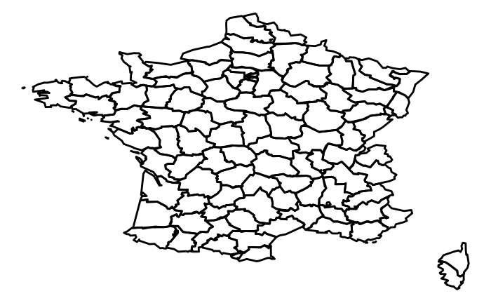

```r
ggplot(fr1)+geom_path(aes(y=lat,x=lon),size=1)+theme_void()
```

# Le package sf

L’approche précédente pour représenter les département en **ggplot** n’est pas vraiment (ou pas du tout) satisfaisante. En effet, nous représentons les latitudes et longitudes sur un repère cartésien 2D. On rappelle que pour visualiser une carte en 2D il faut réaliser des projections. Ces projections peuvent bien entendu se calculer la main mais les packages spécifiques (comme **ggmap**) vont les faire automatiquement. Nous proposons ici de présenter brièvement le package **sf** qui va nous permettre de créer des cartes “avancées”. On pourra trouver de la documentation sur ce package aux url suivantes :

- https://statnmap.com/fr/2018-07-14-initiation-a-la-cartographie-avec-sf-et-compagnie/
- dans les **vignettes** sur la page du cran de ce package : https://cran.r-project.org/web/packages/sf/index.html

Ce package propose de définir un nouveau format **sf** adapté à la cartographie. Regardons par exemple l’objet **nc**

```r
library(sf)
nc <- sf::st_read(system.file("shape/nc.shp", package = "sf"), quiet = TRUE)
nc
```

```
Simple feature collection with 100 features and 14 fields
geometry type:  MULTIPOLYGON
dimension:      XY
bbox:           xmin: -84.32385 ymin: 33.88199 xmax: -75.45698 ymax: 36.58965
epsg (SRID):    4267
proj4string:    +proj=longlat +datum=NAD27 +no_defs
First 10 features:
    AREA PERIMETER CNTY_ CNTY_ID        NAME  FIPS FIPSNO CRESS_ID BIR74 SID74 NWBIR74 BIR79 SID79 NWBIR79                       geometry
1  0.114     1.442  1825    1825        Ashe 37009  37009        5  1091     1      10  1364     0      19 MULTIPOLYGON (((-81.47276 3...
2  0.061     1.231  1827    1827   Alleghany 37005  37005        3   487     0      10   542     3      12 MULTIPOLYGON (((-81.23989 3...
3  0.143     1.630  1828    1828       Surry 37171  37171       86  3188     5     208  3616     6     260 MULTIPOLYGON (((-80.45634 3...
4  0.070     2.968  1831    1831   Currituck 37053  37053       27   508     1     123   830     2     145 MULTIPOLYGON (((-76.00897 3...
5  0.153     2.206  1832    1832 Northampton 37131  37131       66  1421     9    1066  1606     3    1197 MULTIPOLYGON (((-77.21767 3...
6  0.097     1.670  1833    1833    Hertford 37091  37091       46  1452     7     954  1838     5    1237 MULTIPOLYGON (((-76.74506 3...
7  0.062     1.547  1834    1834      Camden 37029  37029       15   286     0     115   350     2     139 MULTIPOLYGON (((-76.00897 3...
8  0.091     1.284  1835    1835       Gates 37073  37073       37   420     0     254   594     2     371 MULTIPOLYGON (((-76.56251 3...
9  0.118     1.421  1836    1836      Warren 37185  37185       93   968     4     748  1190     2     844 MULTIPOLYGON (((-78.30876 3...
10 0.124     1.428  1837    1837      Stokes 37169  37169       85  1612     1     160  2038     5     176 MULTIPOLYGON (((-80.02567 3...
```

Cet objet contient des informations sur les morts subites de nourissons dans des villes de Caroline du Nord. On remarque la présence d’une colonne **geometry** qui permettra de délimiter ces villes à l’aide de polygones. L’objet défini, il est facile de visualiser la carte avec un **plot** classique

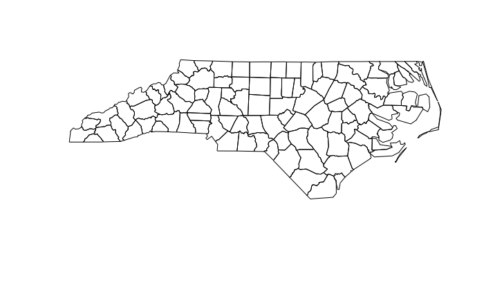

```r
plot(st_geometry(nc))
```

ou avec **ggplot**

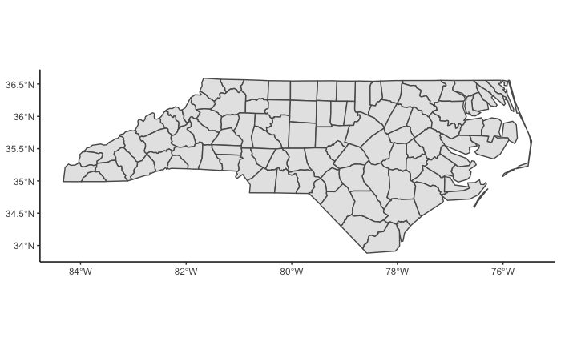

```r
ggplot(nc)+geom_sf()
```

On peut également ajouter des labels dans les polygones

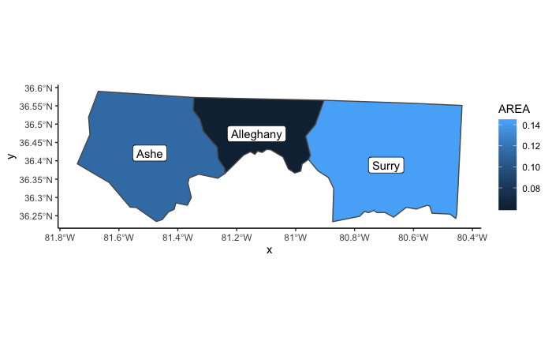

```r
ggplot(nc[1:3,]) +
   geom_sf(aes(fill = AREA)) +
   geom_sf_label(aes(label = NAME))
```

On peut représenter les villes de la table avec

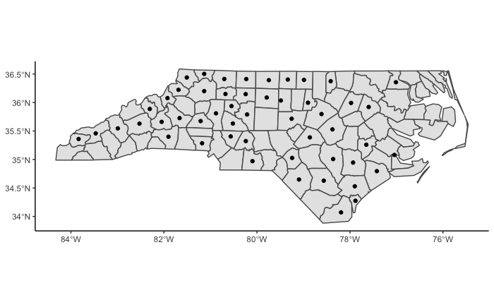

```r
coord.ville <- geocodeGratuit(nc$NAME)
coord.ville1 <- data.frame(coord.ville[,1:2]) %>%
  filter(lon<=-77 & lon>=-85 & lat>=33 & lat<=37) %>%
  as.matrix() %>% st_multipoint() %>% st_geometry()
st_crs(coord.ville1) <- 4326
ggplot(nc)+geom_sf()+geom_sf(data=coord.ville1)
```

Il est souvent préférable de considérer un objet **sf** sous la forme d’un **dataframe** ou **tibble**. On peut par exemple le faire pour l’objet **coord.ville1** avec

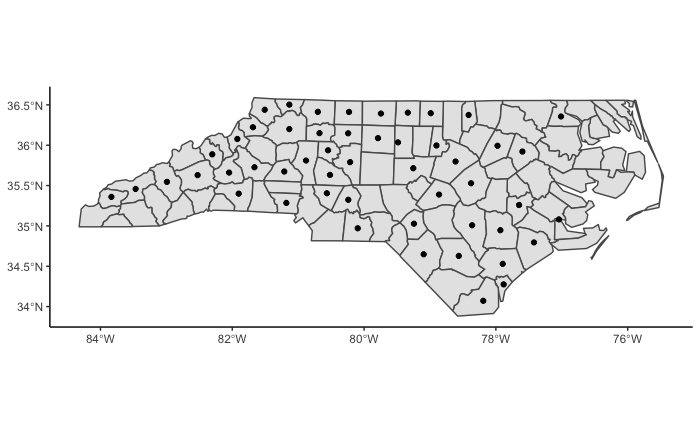

```r
coord.ville2 <- st_cast(coord.ville1, to = "POINT")
nom_ville <- data.frame(coord.ville[,1:2]) %>% mutate(NAME=nc$NAME) %>% filter(lon<=-77 & lon>=-85 & lat>=33 & lat<=37)
df <- data.frame(Ville=nom_ville)
st_geometry(df) <- coord.ville2
st_crs(df) <- 4326
ggplot(nc)+geom_sf()+geom_sf(data=df)
```

### Exercice 2

Nous nous servons de la carte GEOFLAR proposée par l’Institut Géographique National pour récupérer un fond de carte contenant les frontières des départements français. Cette carte est disponible sur le site http: //professionnels.ign.fr/ au format **shapefile**, elle se trouve dans l’archive **dpt.zip**. Il faut décompresser pour reproduire la carte. Grâce au package sf, cette carte, contenue dans la série de fichiers departement du répertoire **dpt**, peut être importée dans un objet R :

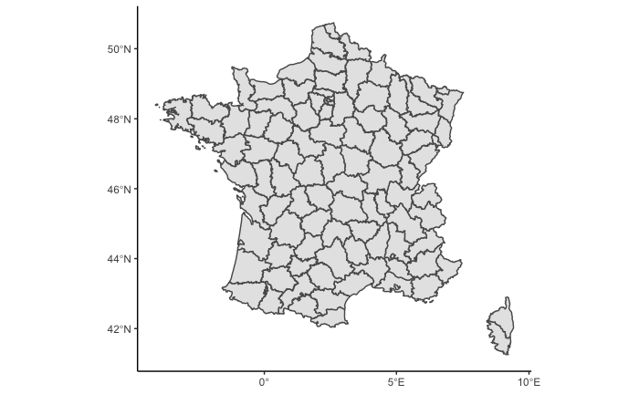

```r
dpt <- read_sf("dpt")
ggplot(dpt) + geom_sf()
```

Refaire la carte de l’exercice 1 sur ce fond de carte.

### Exercice 3

Nous souhaitons visualiser graphiquement les différences de taux de chômage par département entre deux années. Pour cela, nous disposons de chaque taux mesuré aux premiers trimestres des années 2006 et 2011 (variables TCHOMB1T06, TCHOMB1T11) qui se trouvent dans le jeu de données **tauxchomage.csv**

1. Importer le jeu de données.
2. Faire la jointure de cette table avec celle des départements. On pourra utiliser **inner_join**.
3. Comparer les taux de chomage en 2006 et 2011.

### Challenge 1 : carte des températures avec ggmap

1. On importe d’abord les données contenant des températuers observées ainsi que des coordonées de stations.
1. Les fichiers *synop.2018011215.csv* et *postesSynop.csv* contiennent les températures (colonne **t**) du 12 janvier 2018 à 15h et les localisations de 59 stations françaises. Concaténer les deux tables en utilisant comme clef le numéro de la station. On pourra lire les tables avec **read_delim** et faire la jointure avec **inner_join**.
2. Faire de même avec les données actuelles. On pourra requêter directement sur le site des [données publiques de meteo france](https://donneespubliques.meteofrance.fr/?fond=produit&id_produit=90&id_rubrique=32) en utilisant (par exemple) la fonction **fread** du package *data.table* ou la fonction **read_delim** du package *readr*. Convertir les degrés Kelvin en degrés Celsius.
2. Eliminer les stations d’outre mer (on pourra conserver uniquement les stations qui ont une longitude entre -20 et 25). On appellera ce tableau **station1**. Visualiser les stations sur la carte contenant les frontières des départements français.
3. Créer un dataframe au format **sf** qui contient les températures des stations ainsi que leurs coordonnées dans la colonne **geometry**. On pourra commencer avec

```r
station2 <- station1 %>% select(Longitude,Latitude) %>% as.matrix() %>% st_multipoint() %>% st_geometry()
st_crs(station2) <- 4326
station2 <- st_cast(station2, to = "POINT")
```

4. Représenter les stations sur une carte de france. On pourra mettre un point de couleur différente en fonction de la température.
5. On obtient les cordonnées des centroïdes des départements à l’aide de

```r
centro <- st_centroid(dpt$geometry)
centro <- st_transform(centro,crs=4326)
```

On déduit les distances entre ces centroïdes et les stations avec (**df** étant la table **sf** obtenue à la question 3).

```r
DD <- st_distance(df,centro)
```

Prédire la température de chaque département à l’aide de la règle du 1 plus proche voisin.

6. Colorier les départements en fonction de la température prédite dans le département. On pourra faire varier le dégradé de couleur du jaune (pour les faibles températures) au rouge (pour les fortes).

# Le package **leaflet**

**Leaflet** est un package permettant de faire de la *cartographie intéractive*. On pourra consulter un descriptif synthétique [ici](https://rstudio.github.io/leaflet/). On peut par exemple obtenir un fond de carte de la terre avec

```r
library(leaflet)
m <- leaflet()
m <- addTiles(m)
m
```

[interactive chart not shown]

Ou de manière équivalente avec *dplyr*

```r
leaflet() %>% addTiles()
```

[interactive chart not shown]

On dispose de plusieurs styles de fonds de cartes (quelques exemples [ici](http://leaflet-extras.github.io/leaflet-providers/preview/)) :

```r
Paris <- geocodeGratuit("paris")
m2 <- leaflet() %>% setView(lng = Paris[1], lat = Paris[2], zoom = 12) %>%
  addTiles()
m2 %>% addProviderTiles("Stamen.Toner")
```

[interactive chart not shown]

```r
m2 %>% addProviderTiles("OpenStreetMap.BlackAndWhite")
```

[interactive chart not shown]

```r
m2 %>% addProviderTiles("Thunderforest.Transport")
```

[interactive chart not shown]

On pourra placer des *markers* sur la carte avec des commandes telles que **addMarkers** ou **addCircles**…

```r
data(quakes)
leaflet(data = quakes[1:20,]) %>% addTiles() %>%
  addMarkers(~long, ~lat, popup = ~as.character(mag))
```

[interactive chart not shown]

Les **popups** permettent d’ajouter des informations auxiliaires lorsqu’on clique sur un marker dans la carte :

```r
content <- paste(sep = "<br/>",
  "<b><a href='http://www.samurainoodle.com'>Samurai Noodle</a></b>",
  "606 5th Ave. S",
  "Seattle, WA 98138"
)

leaflet() %>% addTiles(urlTemplate = "http://{s}.tile.openstreetmap.org/{z}/{x}/{y}.png") %>%
  addPopups(-122.327298, 47.597131, content,
    options = popupOptions(closeButton = FALSE)
  )
```

[interactive chart not shown]

### Exercice 4

Placer un *popup* représentant l’Université Rennes 2 (Campus Villejean). On ajoutera un lien renvoyant sur le sité de l’Université.

### Challenge 2 : Velib Paris

Plusieurs villes dans le monde ont accepté de mettre en ligne les données sur l’occupation des stations velib dans leur ville. Ces données sont facilement accessibles et mises à jour en temps réel. On dispose généralement de la taille et la localisation des stations, la proportion de vélos disponibles… Il est possible de requêter (entre autres) :

- sur les données [Decaux](https://developer.jcdecaux.com/#/opendata/vls?page=getstarted)
- sur [Open data Paris](https://opendata.paris.fr/pages/home/)
- sur [vlstats](http://vlsstats.ifsttar.fr/rawdata) pour des données mensuelles ou historiques ou encore sur Velib pour obtenir des fichiers qui sont rafraichis régulièrement.
1. Récupérer les données actuelles de velib disponibles pour la ville de Paris : https://opendata.paris.fr/explore/dataset/velib-disponibilite-en-temps-reel/information/. On pourra utiliser la fonction *url* dans **read.csv**.
2. Décrire les variables du jeu de données.
3. Créer les une variable **latitude** et une variable **longitude** à partir de la variable **geo**.
4. Visualiser les positions des stations sur une carte leaflet.
5. Ajouter un popup qui permet de connaitre le nombre de vélos disponibles (électriques+mécanique) quand on clique sur la station (on pourra utiliser l’option **popup** dans la fonction **addCircleMarkers**).
6. Ajouter la nom de la station dans le popup.
7. Faire de même en utilisant des couleurs différentes en fonction de la proportion de vélos disponibles dans la station. On pourra utiliser les palettes de couleur

```r
ColorPal1 <- colorNumeric(scales::seq_gradient_pal(low = "#132B43", high = "#56B1F7", space = "Lab"), domain = c(0,1))
ColorPal2 <- colorNumeric(scales::seq_gradient_pal(low = "red", high = "black", space = "Lab"), domain = c(0,1))
```

### Exercice 5

Refaire la carte des températures du premier challenge en utilisant **leaflet**. On utilisera la table construite dans le challenge 1 et la fonction **addPolygons**. On pourra également ajouter un popup qui permet de visualiser le nom du département ainsi que la température prévue lorsqu’on clique dessus.